# Homework 3

```r
arima_model <- sarima(ts_df$Value, p=1, d=0, q=2, details = TRUE)
```

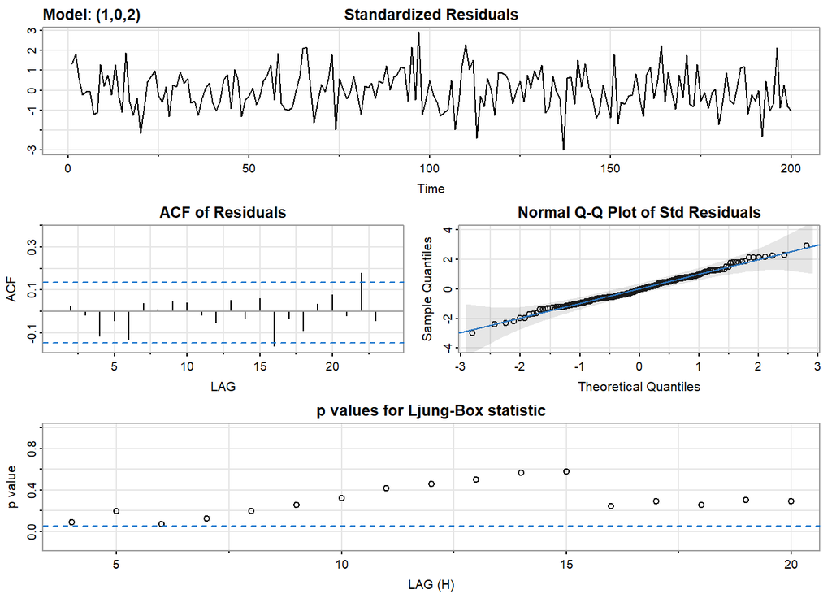

Since there is no clear pattern shown in the residual plot for our ARMA model, as well as our p-value in the Box-Ljung test on the residuals of the model not being significant, we can assume the ARMA model fits our time series

```r
arima_model$ttable
```

```
##       Estimate     SE t.value p.value
## ar1     0.3911 0.1702  2.2974  0.0227
## ma1     0.5086 0.1723  2.9514  0.0035
## ma2    -0.0096 0.1439 -0.0667  0.9469
## xmean   6.6282 0.2143 30.9266  0.0000
```

however, the one issue I’ve found is that the coefficient for our second lag in the acf plot in the arima model is not significant, and doesn’t indicate a stationary process, so I will again try this again but removing the second lag from teh model, thus making the q value 1 rather than 2

```r
arima_model2 <- sarima(ts_df$Value, p=1, d=0, q=1, details = TRUE)
```

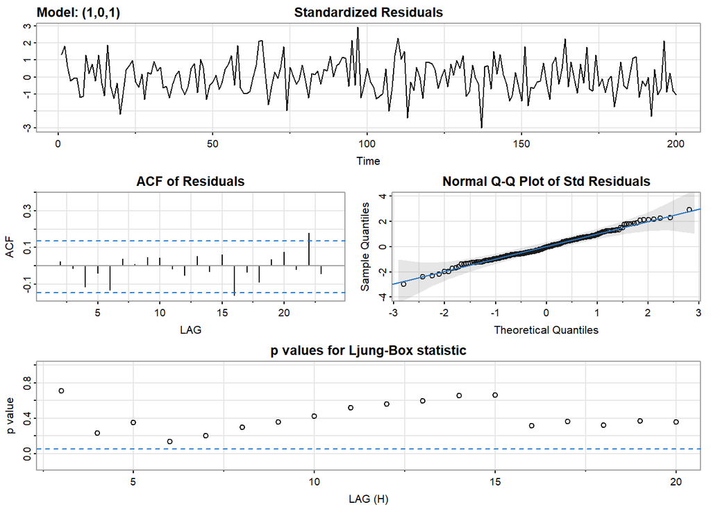

```r
arima_model2$ttable
```

```
##       Estimate     SE t.value p.value
## ar1     0.3814 0.0928  4.1092   1e-04
## ma1     0.5184 0.0919  5.6390   0e+00
## xmean   6.6282 0.2137 31.0139   0e+00
```

Here we can see that we now only included the first lag from both the acf and pacf plots, and it gives us significant coefficients less than 1, thus showing a better fit that indicates a stationary process. However, the only concern I have it that the p-value for our ma1 coefficient is basically 0, which may indicate some kind of overfitting of the model. As such, I would actually argue that we use the first of the two arima models, as this model seems unreliable.

```r
model1 <- dynlm::dynlm(Value ~ lag(Value, 1) + lag(Value, 2) + x, data = ts_df)

summary(model1)$r.squared
```

```
## [1] 1
```

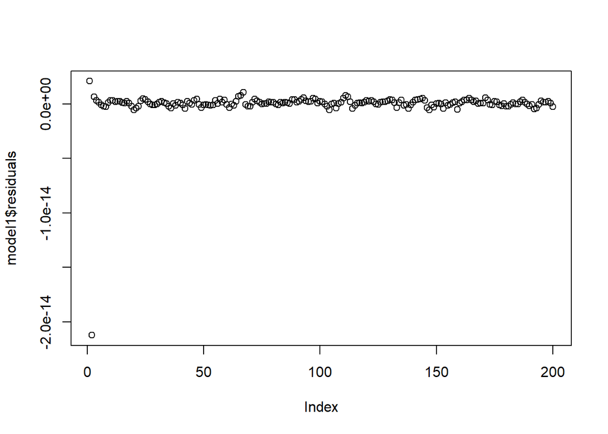

```r
plot(model1$residuals)
```